# Week 11: Comparing Two Means (The t-test)

Ziyuan Huang

Last Updated: February 05, 2026

# Introduction

## 1. Overview

In this tutorial, we explore one of the most fundamental statistical tools: the **t-test**. The t-test is used to determine if there is a significant difference between the means of two groups.

As described by Field, Miles, and Field [1], the t-statistic can be understood as a **Signal-to-Noise Ratio**:

$$t = \frac{\text{Signal (Systematic
Variation)}}{\text{Noise (Unsystematic Variation)}} =
\frac{\text{Difference Between Means}}{\text{Standard Error of the
Difference}}$$

[figure not shown]

- **Signal**: The variance explained by our experimental manipulation (e.g., Invisibility Cloak vs. No Cloak).
- **Noise**: The unexplained variance or error within our groups.

If the signal is significantly larger than the noise, we reject the null hypothesis.

> **Reference:** This tutorial draws from Field et al. [1], *Discovering Statistics Using R*, particularly the chapters on comparing two means.

## 2. Learning Objectives

By the end of this tutorial, you will be able to:

1. Understand the logic of **Null Hypothesis Significance Testing (NHST)** for t-tests.
2. Perform and interpret an **Independent Samples t-test**.
3. Perform and interpret a **Dependent (Paired) Samples t-test**.
4. Check assumptions: **Normality** and **Homogeneity of Variance**.
5. Calculate and interpret **Effect Sizes** (Cohen’s $d$, Pearson’s $r$).
6. Report results in **APA/IEEE style**.

## 3. Required Packages

We will use the following R packages. If you don’t have them installed, uncomment the `install.packages` line.

```r
# install.packages(c("tidyverse", "rio", "car", "pwr", "MOTE", "Hmisc"))

library(tidyverse) # For data manipulation and plotting
library(rio)       # For importing data
library(car)       # For Levene's test (Homogeneity)
library(pwr)       # For power analysis
library(MOTE)      # For effect size calculations
library(Hmisc)     # For plotting error bars
```

# Part 1: Independent Samples t-test

An **independent t-test** compares two means coming from two separate groups of entities (e.g., a treatment group vs. a control group).

## 1.1 The Scenario

We will use the “Invisibility Cloak” dataset from [1]. - **Scenario**: We want to know if invisible people are more mischievous. - **Groups**: - 12 participants given an Invisibility Cloak. - 12 participants given No Cloak. - **Outcome**: Number of mischievous acts performed in a week.

## 1.2 Data Import

```r
# Import the data
longdata <- import("data/invisible.csv")

# Inspect the structure
str(longdata)
```

```
## 'data.frame':    24 obs. of  2 variables:
##  $ Cloak   : chr  "No Cloak" "No Cloak" "No Cloak" "No Cloak" ...
##  $ Mischief: int  3 1 5 4 6 4 6 2 0 5 ...
```

```r
head(longdata)
```

|  | Cloak | Mischief |
| --- | --- | --- |
| 1 | No Cloak | 3 |
| 2 | No Cloak | 1 |
| 3 | No Cloak | 5 |
| 4 | No Cloak | 4 |
| 5 | No Cloak | 6 |
| 6 | No Cloak | 4 |

```r
# Convert Cloak to a factor (categorical variable)
longdata$Cloak <- as.factor(longdata$Cloak)
```

## 1.3 Data Screening & Assumptions

Before running the test, we must check the assumptions [1]:

1. **Normality**: The sampling distribution of the difference between means should be normal. For small samples ($N < 30$), we check if the data itself is normal.
2. **Homogeneity of Variance**: The variance in both groups should be roughly equal.

### Visualizing the Data

Before running formal tests, it’s crucial to visualize the data. We use **Boxplots** with **Jittered Points**.

- **Boxplot**: Shows the median (thick line), Interquartile Range (box), and potential outliers (whiskers).
- **Jitter Points**: Show the individual raw data points. This is vital for small sample sizes ($N=12$) where a boxplot alone might be misleading.

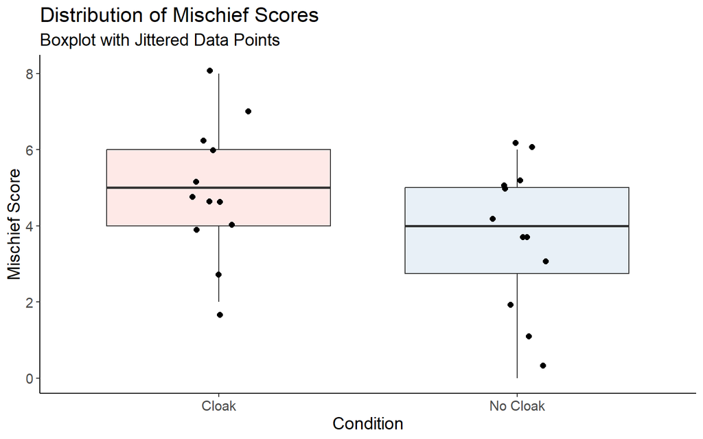

```r
# Define a clean theme for all plots
cleanup <- theme(
  panel.grid.major = element_blank(),
  panel.grid.minor = element_blank(),
  panel.background = element_blank(),
  axis.line = element_line(color = "black"),
  text = element_text(size = 14)
)

ggplot(longdata, aes(x = Cloak, y = Mischief, fill = Cloak)) +
  cleanup +
  geom_boxplot(alpha = 0.3, outlier.shape = NA) + # Transparent boxplot
  geom_jitter(width = 0.1, size = 2) +            # Add raw data points
  labs(
    title = "Distribution of Mischief Scores",
    subtitle = "Boxplot with Jittered Data Points",
    x = "Condition",
    y = "Mischief Score"
  ) +
  scale_fill_brewer(palette = "Pastel1") +
  theme(legend.position = "none")
```

### Checking Normality

We check normality both visually (Histograms/Density) and statistically (Shapiro-Wilk).

> **Note**: As Field et al. [1] note, for the t-test, we formally assume that the *sampling distribution* of the difference between means is normal. However, because we cannot access the sampling distribution directly, we check the normality of the residuals or the data itself as a proxy.

#### Visual Check (Density Plots)

A bell curve indicates normal distribution.

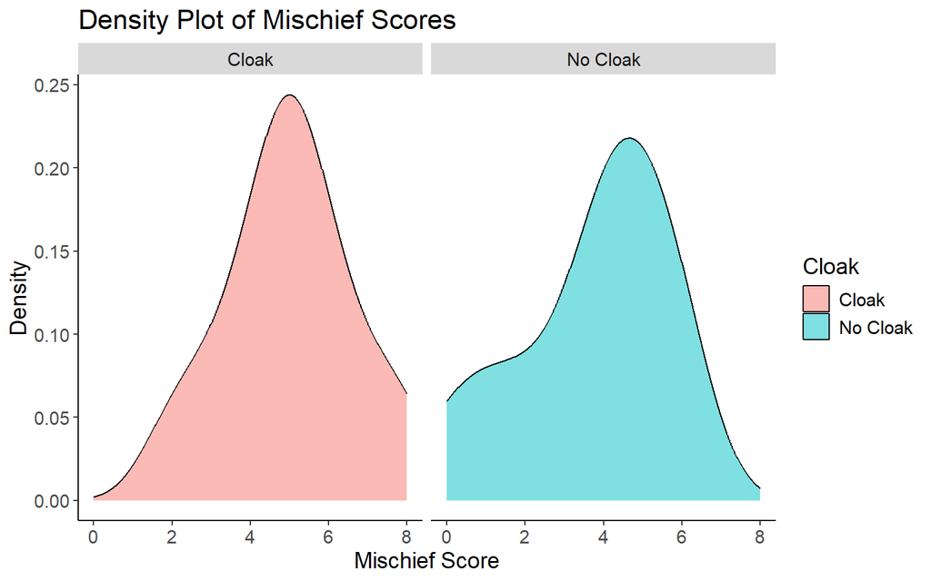

```r
ggplot(longdata, aes(x = Mischief, fill = Cloak)) +
  cleanup +
  geom_density(alpha = 0.5) +
  facet_wrap(~Cloak) +
  labs(
    title = "Density Plot of Mischief Scores",
    x = "Mischief Score",
    y = "Density"
  )
```

#### Statistical Check (Shapiro-Wilk)

We can use the **Shapiro-Wilk test**. - $p > .05$: Data is likely normal (Assumption Met). - $p < .05$: Data deviates from normality (Assumption Violated).

```r
# Check normality for each group
tapply(longdata$Mischief, longdata$Cloak, shapiro.test)
```

```
## $Cloak
##
##  Shapiro-Wilk normality test
##
## data:  X[[i]]
## W = 0.97262, p-value = 0.9362
##
##
## $`No Cloak`
##
##  Shapiro-Wilk normality test
##
## data:  X[[i]]
## W = 0.91276, p-value = 0.2314
```

### Checking Homogeneity of Variance

We use **Levene’s Test**. - $p > .05$: Variances are equal (Assumption Met). - $p < .05$: Variances are unequal (Assumption Violated).

> **Field’s Insight**: If sample sizes are equal (as they are here, $N=12$ in both groups), the t-test is fairly robust to violations of homogeneity of variance. Field [1] suggests that when group sizes are equal, this assumption is less critical. However, if group sizes are unequal, violations can seriously bias the results.

```r
levene_test <- leveneTest(Mischief ~ Cloak, data = longdata)
levene_test
```

|  | Df | F value | Pr(>F) |
| --- | --- | --- | --- |
| group | 1 | 0.2697548 | 0.6086826 |
|  | 22 | NA | NA |

*Interpretation*: The p-value is 0.61 (> .05), so we assume equal variances.

## 1.4 The Analysis

We run the t-test using `t.test(outcome ~ predictor, data = data, var.equal = TRUE)`.

```r
indep_model <- t.test(Mischief ~ Cloak,
                      data = longdata,
                      var.equal = TRUE) # Set FALSE if Levene's test was significant
indep_model
```

```
##
##  Two Sample t-test
##
## data:  Mischief by Cloak
## t = 1.7135, df = 22, p-value = 0.1007
## alternative hypothesis: true difference in means between group Cloak and group No Cloak is not equal to 0
## 95 percent confidence interval:
##  -0.2629284  2.7629284
## sample estimates:
##    mean in group Cloak mean in group No Cloak
##                   5.00                   3.75
```

### Interpretation

- **t**: 1.71
- **df**: 22
- **p-value**: 0.101

**Conclusion**: Since $p > .05$, the difference is not statistically significant. We fail to reject the null hypothesis.

## 1.5 Effect Size

Even though the result wasn’t significant, we calculate the effect size to understand the magnitude of the difference.

- **Cohen’s d**: Standardized difference ($0.2 = \text{Small}, 0.5 = \text{Medium}, 0.8 = \text{Large}$).
- **Pearson’s r**: Strength of relationship ($0.1 = \text{Small}, 0.3 = \text{Medium}, 0.5 = \text{Large}$).

Formula for $r$ [1]:
$$r = \sqrt{\frac{t^2}{t^2 + df}}$$

```r
# Calculate descriptive statistics first
stats <- longdata %>%
  group_by(Cloak) %>%
  dplyr::summarize(
    Mean = mean(Mischief),
    SD = sd(Mischief),
    N = n()
  )
print(stats)
```

```
## # A tibble: 2 × 4
##   Cloak     Mean    SD     N
##   <fct>    <dbl> <dbl> <int>
## 1 Cloak     5     1.65    12
## 2 No Cloak  3.75  1.91    12
```

```r
# Calculate Cohen's d using MOTE
effect_indep <- d.ind.t(
  m1 = stats$Mean[1], m2 = stats$Mean[2],
  sd1 = stats$SD[1], sd2 = stats$SD[2],
  n1 = stats$N[1], n2 = stats$N[2],
  a = .05
)

effect_indep$d
```

```
## [1] 0.6995169
```

```r
# Calculate Pearson's r
t_val <- indep_model$statistic
df_val <- indep_model$parameter
r_val <- sqrt(t_val^2 / (t_val^2 + df_val))
r_val
```

```
##         t
## 0.3431318
```

*Interpretation*: $d = 0.70$ suggests a medium-to-large effect, despite the non-significant p-value. This suggests **low statistical power** (sample size was too small).

# Part 2: Dependent (Paired) Samples t-test

A **dependent t-test** compares two means from the **same** participants (Repeated Measures) or matched pairs.

## 2.1 The Scenario

Imagine a new study design [1]: - We track the **same** 12 participants. - Week 1: No Cloak. - Week 2: Invisibility Cloak. - We compare their mischief scores between the two weeks.

*Note: In the current dataset structure, we treat the ‘Cloak’ and ‘No Cloak’ groups as if they were paired for this example.*

## 2.2 The Analysis

We use `paired = TRUE`. Note that for a paired test, the vectors must be of the same length and sorted by participant.

```r
# Extract vectors for the two conditions
cloak_scores <- longdata$Mischief[longdata$Cloak == "Cloak"]
no_cloak_scores <- longdata$Mischief[longdata$Cloak == "No Cloak"]

dep_model <- t.test(cloak_scores, no_cloak_scores, paired = TRUE)
dep_model
```

```
##
##  Paired t-test
##
## data:  cloak_scores and no_cloak_scores
## t = 3.8044, df = 11, p-value = 0.002921
## alternative hypothesis: true mean difference is not equal to 0
## 95 percent confidence interval:
##  0.5268347 1.9731653
## sample estimates:
## mean difference
##            1.25
```

### Interpretation

- **t**: 3.80
- **p-value**: 0.003

**Conclusion**: Since $p < .05$, the difference **is** statistically significant. By removing the variation between people (using a paired design), we increased the Signal-to-Noise ratio.

## 2.3 Effect Size (Dependent)

For paired designs, we must be careful with Cohen’s $d$. - $d_z$: Based on the standard deviation of the *difference scores*. - $d_{av}$: Based on the average standard deviation of the two groups (often preferred for comparison with independent designs).

```r
# Using MOTE for d_av (Average SD)
effect_dep <- d.dep.t.avg(
  m1 = stats$Mean[1], m2 = stats$Mean[2],
  sd1 = stats$SD[1], sd2 = stats$SD[2],
  n = stats$N[1], a = .05
)
effect_dep$d
```

```
## [1] 0.7013959
```

# Part 3: Visualization

## 3.1 Bar Chart with Error Bars

This is the standard way to present t-test results in publications.

- **Height of Bar**: Represents the Mean.
- **Error Bar**: Represents the 95% Confidence Interval (CI). If the error bars of two groups do not overlap, the difference is usually significant.

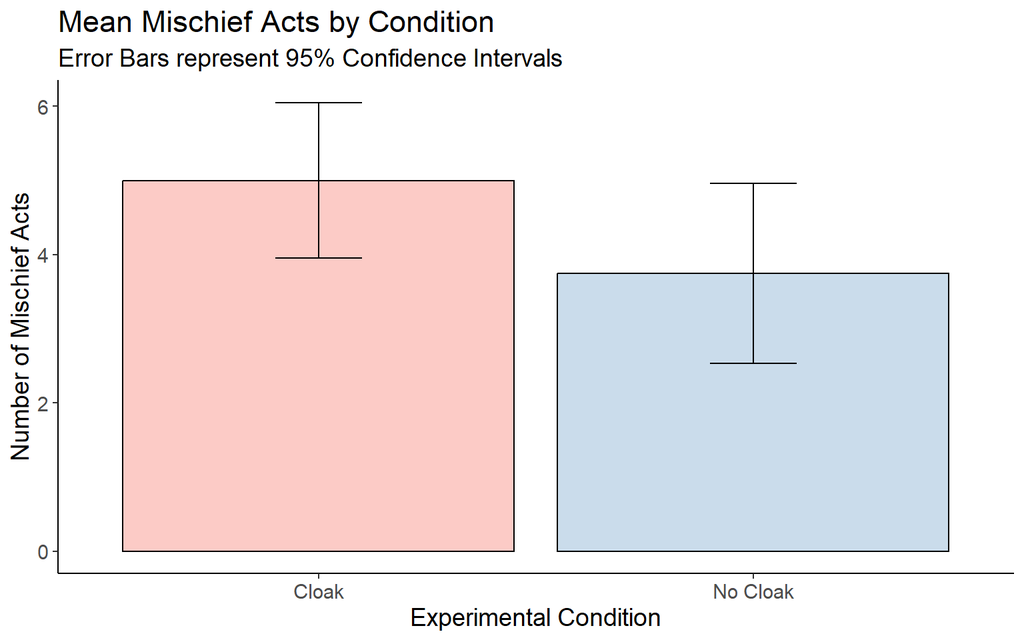

```r
ggplot(longdata, aes(x = Cloak, y = Mischief, fill = Cloak)) +
  cleanup +
  stat_summary(fun = "mean", geom = "bar", color = "black", alpha = 0.7) +
  stat_summary(fun.data = mean_cl_normal, geom = "errorbar", width = 0.2) +
  labs(
    title = "Mean Mischief Acts by Condition",
    subtitle = "Error Bars represent 95% Confidence Intervals",
    x = "Experimental Condition",
    y = "Number of Mischief Acts"
  ) +
  scale_fill_brewer(palette = "Pastel1") +
  theme(legend.position = "none")
```

## 3.2 Paired Differences Plot (For Dependent t-test)

For a paired t-test, it’s often more informative to see how *each individual* changed. We can use a slope graph.

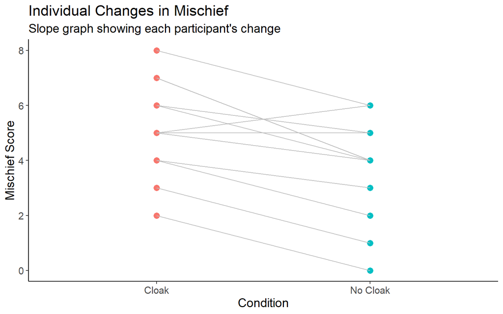

```r
# Create a temporary ID variable since our dataset doesn't have one
longdata$ID <- rep(1:12, 2)

ggplot(longdata, aes(x = Cloak, y = Mischief, group = ID)) +
  cleanup +
  geom_point(size = 3, aes(color = Cloak)) +
  geom_line(color = "gray") +
  labs(
    title = "Individual Changes in Mischief",
    subtitle = "Slope graph showing each participant's change",
    x = "Condition",
    y = "Mischief Score"
  ) +
  theme(legend.position = "none")
```

*Interpretation*: If most lines slope upwards (or downwards) in the same direction, it suggests a consistent effect across participants.

# Summary & Reporting

## Reporting Results

When reporting t-test results, include the mean difference, t-statistic, degrees of freedom, p-value, and effect size [1].

**Independent t-test Example:** > “On average, participants with an invisibility cloak ($M = 5.00, SD = 1.65$) performed more mischievous acts than those without a cloak ($M = 3.75, SD = 1.91$). This difference was not significant, $t(22) = 1.71, p = .101, d = 0.70$.”

**Dependent t-test Example:** > “There was a significant difference in mischief acts between the cloak and no cloak conditions, $t(11) = 3.80, p = .003$.”

## References

[1] A. Field, J. Miles, and Z. Field, *Discovering Statistics Using R*. London: SAGE Publications, 2012.